# Análisis Causal del Efecto de la Salida de Erin Ledell en H2O-3

Análisis de Series Temporales Interrumpidas

02 de November de 2025

# Resumen Ejecutivo

Este documento presenta un **análisis causal exhaustivo** del impacto de la salida de **Erin Ledell** (Chief Machine Learning Scientist) en el desarrollo de la librería **H2O-3**. Utilizando múltiples metodologías estadísticas incluyendo Análisis de Series Temporales Interrumpidas (ITS), pruebas de diferencia de medias, y análisis de regresión, evaluamos el efecto de esta transición organizacional en la actividad de desarrollo.

**Hallazgos principales:** - Reducción estadísticamente significativa en la actividad de desarrollo post-salida - Cambios en el ritmo de liberación de versiones - Disminución en todos los tipos de cambios (funcionalidades, bugs, mejoras, documentación)

# 1 Introducción

## 1.1 Contexto del Análisis

**H2O-3** es una plataforma de machine learning de código abierto ampliamente utilizada en la industria. **Erin Ledell** se desempeñó como Chief Machine Learning Scientist y fue una figura clave en el desarrollo y dirección técnica del proyecto.

**Fecha de salida:** 28 de marzo de 2024

Este análisis busca cuantificar el impacto de su salida en la actividad de desarrollo del proyecto, utilizando datos de 160 versiones liberadas entre abril de 2016 y octubre de 2025.

## 1.2 Pregunta de Investigación

**¿Tuvo la salida de Erin Ledell un efecto causal significativo en la actividad de desarrollo de H2O-3?**

Para responder esta pregunta, empleamos un diseño cuasi-experimental con series temporales interrumpidas, que permite estimar efectos causales en contextos donde no es posible realizar experimentos controlados.

## 1.3 Datos

El dataset incluye las siguientes variables para cada versión:

- **version**: Número de versión
- **date**: Fecha de liberación (MM/DD/YYYY)
- **new_features**: Número de nuevas funcionalidades
- **bugs**: Número de bugs corregidos
- **improvements**: Número de mejoras implementadas
- **docs**: Actualizaciones de documentación

# 2 Preparación de Datos

## 2.1 Carga de Librerías

```r
# Instalación y carga de paquetes
instalar_si_necesario <- function(paquete) {
  if (!require(paquete, character.only = TRUE, quietly = TRUE)) {
    install.packages(paquete, repos = "https://cloud.r-project.org/")
    library(paquete, character.only = TRUE)
  }
}

paquetes <- c("tidytable", "ggplot2", "lubridate", "scales",
    "patchwork", "lmtest", "sandwich", "forecast",
    "tseries", "changepoint", "knitr", "kableExtra")

invisible(sapply(paquetes, instalar_si_necesario))
```

## 2.2 Carga y Transformación de Datos

```r
# Cargar datos
library(janitor)
datos <- tidytable::fread("h2o_versions_data.csv") %>% clean_names()

# Transformaciones con tidytable
datos <- datos %>%
  tidytable::mutate(
    fecha = mdy(date),  # Parsear fecha
    fecha_intervencion = as.Date("2024-03-28"),  # Fecha de salida
    post_salida = tidytable::if_else(fecha >= fecha_intervencion, 1, 0),  # Indicador pre/post
    periodo = tidytable::if_else(post_salida == 1, "Post-salida", "Pre-salida"),

    # Variables de tiempo en días
    tiempo_dias = as.numeric(fecha - min(fecha, na.rm = TRUE)),
    tiempo_desde_intervencion = as.numeric(fecha - fecha_intervencion),
    tiempo_post = pmax(0, tiempo_desde_intervencion),  # Tiempo post-intervención (0 antes, positivo después)

    # Variables de tiempo en meses (aproximado, usando días/30.44)
    meses_pasados = floor(tiempo_dias / 30.44),  # Meses desde el inicio
    meses_desde_intervencion = floor(tiempo_desde_intervencion / 30.44),
    meses_post = pmax(0, meses_desde_intervencion),  # Meses post-intervención

    # Total de cambios
    total_cambios = new_features + bugs + improvements + docs,

    # Índice de versión
    version_num = row_number()
  ) %>%
  tidytable::arrange(fecha) %>%
  tidytable::mutate(
    dias_desde_anterior = tidytable::if_else(
      version_num == 1,
      0,
      as.numeric(fecha - lag(fecha))
    )
  )
```

## 2.3 Descripción del Dataset

```r
cat(sprintf("📊 Total de versiones analizadas: %d
", nrow(datos)))
```

```
## 📊 Total de versiones analizadas: 160
```

```r
cat(sprintf("📅 Periodo de análisis: %s a %s
", min(datos$fecha), max(datos$fecha)))
```

```
## 📅 Periodo de análisis: 2016-04-07 a 2025-10-08
```

```r
cat(sprintf("⏮️  Versiones pre-salida: %d (%.1f%%)
",
    sum(datos$post_salida == 0),
    (sum(datos$post_salida == 0) / nrow(datos)) * 100))
```

```
## ⏮️  Versiones pre-salida: 154 (96.2%)
```

```r
cat(sprintf("⏭️  Versiones post-salida: %d (%.1f%%)
",
    sum(datos$post_salida == 1),
    (sum(datos$post_salida == 1) / nrow(datos)) * 100))
```

```
## ⏭️  Versiones post-salida: 6 (3.8%)
```

# 3 Análisis Descriptivo

## 3.1 Estadísticas Descriptivas por Periodo

```r
stats_periodo <- datos %>%
  tidytable::summarise(
    `N` = n(),
    `Features (Media)` = sprintf("%.2f", mean(new_features, na.rm = TRUE)),
    `Features (Mediana)` = sprintf("%.1f", median(new_features, na.rm = TRUE)),
    `Bugs (Media)` = sprintf("%.2f", mean(bugs, na.rm = TRUE)),
    `Bugs (Mediana)` = sprintf("%.1f", median(bugs, na.rm = TRUE)),
    `Mejoras (Media)` = sprintf("%.2f", mean(improvements, na.rm = TRUE)),
    `Mejoras (Mediana)` = sprintf("%.1f", median(improvements, na.rm = TRUE)),
    `Docs (Media)` = sprintf("%.2f", mean(docs, na.rm = TRUE)),
    `Total (Media)` = sprintf("%.2f", mean(total_cambios, na.rm = TRUE)),
    `Días entre versiones (Media)` = sprintf("%.1f",
                                            mean(dias_desde_anterior[dias_desde_anterior > 0], na.rm = TRUE)),
    .by = periodo
  )

kable(stats_periodo,
    caption = "Tabla 1: Estadísticas descriptivas por periodo",
    align = "lrrrr") %>%
  kable_styling(bootstrap_options = c("striped", "hover", "condensed"),
    full_width = FALSE)
```

Tabla 1: Estadísticas descriptivas por periodo

| periodo | N | Features (Media) | Features (Mediana) | Bugs (Media) | Bugs (Mediana) | Mejoras (Media) | Mejoras (Mediana) | Docs (Media) | Total (Media) | Días entre versiones (Media) |
| --- | --- | --- | --- | --- | --- | --- | --- | --- | --- | --- |
| Post-salida | 6 | 0.50 | 0.5 | 3.00 | 3.0 | 0.67 | 0.0 | 2.67 | 6.83 | 95.7 |
| Pre-salida | 154 | 2.23 | 0.0 | 5.66 | 3.5 | 2.60 | 1.0 | 3.19 | 13.68 | 19.1 |

### 3.1.1 Interpretación

La tabla anterior muestra diferencias notables entre los periodos pre y post salida de Erin Ledell:

- Las **nuevas funcionalidades** muestran una reducción en el periodo post-salida
- La **corrección de bugs** también presenta una disminución
- El **tiempo promedio entre versiones** se incrementa, indicando un ritmo más lento

# 4 Análisis Causal

## 4.1 Metodología: Análisis de Series Temporales Interrumpidas (ITS)

El **Análisis de Series Temporales Interrumpidas (Interrupted Time Series, ITS)** es una metodología cuasi-experimental que permite estimar efectos causales cuando existe una intervención claramente definida en el tiempo.

### 4.1.1 Modelo ITS

El modelo básico es:

$$Y_t = \beta_0 + \beta_1 \cdot meses\_pasados_t + \beta_2 \cdot
post\_salida_t + \beta_3 \cdot meses\_post_t + \epsilon_t$$

Donde:

- $\beta_0$ = nivel basal (intercepto)
- $\beta_1$ = tendencia pre-intervención
- $\beta_2$ = **cambio inmediato en el nivel** (level change)
- $\beta_3$ = **cambio en la tendencia** (slope change)
- $\epsilon_t$ = término de error

### 4.1.2 Interpretación de Parámetros

- **$\beta_2$ (Level Change):** Representa el cambio inmediato en el nivel de la variable dependiente justo después de la intervención.
- **$\beta_3$ (Slope Change):** Representa cómo cambia la tendencia temporal después de la intervención.

## 4.2 Modelo ITS para Total de Cambios

```r
# Modelo ITS principal usando meses
modelo_its_total <- lm(
  total_cambios ~ meses_pasados + post_salida + meses_post,
  data = datos
)

# Errores estándar robustos (Newey-West para autocorrelación)
coeftest_total <- coeftest(modelo_its_total, vcov = NeweyWest(modelo_its_total))

# Mostrar resultados
cat("════
")
```

```
## ════
```

```r
cat("MODELO ITS: TOTAL DE CAMBIOS
")
```

```
## MODELO ITS: TOTAL DE CAMBIOS
```

```r
cat("════

")
```

```
## ════
```

```r
print(coeftest_total)
```

```
##
## t test of coefficients:
##
##                 Estimate Std. Error t value  Pr(>|t|)
## (Intercept)     9.086763   2.666610  3.4076 0.0008339 ***
## meses_pasados   0.117042   0.047574  2.4602 0.0149768 *
## post_salida   -12.134768   3.317872 -3.6574 0.0003479 ***
## meses_post     -0.317326   0.163127 -1.9453 0.0535408 .
## ---
## Signif. codes:  0 '***' 0.001 '**' 0.01 '*' 0.05 '.' 0.1 ' ' 1
```

```r
cat(sprintf("
R² = %.4f
", summary(modelo_its_total)$r.squared))
```

```
##
## R² = 0.0374
```

```r
cat(sprintf("R² ajustado = %.4f
", summary(modelo_its_total)$adj.r.squared))
```

```
## R² ajustado = 0.0189
```

```r
cat("════
")
```

```
## ════
```

### 4.2.1 Interpretación del Modelo ITS

```r
coefs <- coef(modelo_its_total)
pvals <- coeftest_total[, "Pr(>|t|)"]

cat("
📊 INTERPRETACIÓN DE RESULTADOS:

")
```

```
##
## 📊 INTERPRETACIÓN DE RESULTADOS:
```

```r
cat(sprintf("1️⃣  NIVEL BASAL (Intercepto): %.2f cambios
", coefs[1]))
```

```
## 1️⃣  NIVEL BASAL (Intercepto): 9.09 cambios
```

```r
cat("    → Nivel promedio de cambios al inicio del periodo

")
```

```
##     → Nivel promedio de cambios al inicio del periodo
```

```r
cat(sprintf("2️⃣  TENDENCIA PRE-SALIDA: %.6f cambios por mes
", coefs[2]))
```

```
## 2️⃣  TENDENCIA PRE-SALIDA: 0.117042 cambios por mes
```

```r
cat("    → Crecimiento mensual en el periodo pre-salida
")
```

```
##     → Crecimiento mensual en el periodo pre-salida
```

```r
cat(sprintf("    → Anualizado: %.2f cambios por año
", coefs[2] * 12))
```

```
##     → Anualizado: 1.40 cambios por año
```

```r
if (pvals[2] < 0.05) {
  cat("    ✅ Estadísticamente significativo (p < 0.05)

")
} else {
  cat("    ⚠️  No significativo (p ≥ 0.05)

")
}
```

```
##     ✅ Estadísticamente significativo (p < 0.05)
```

```r
cat(sprintf("3️⃣  CAMBIO INMEDIATO (Level Change): %.2f cambios
", coefs[3]))
```

```
## 3️⃣  CAMBIO INMEDIATO (Level Change): -12.13 cambios
```

```r
cat("    → Cambio en el nivel inmediatamente después de la salida
")
```

```
##     → Cambio en el nivel inmediatamente después de la salida
```

```r
if (coefs[3] < 0) {
  cat(sprintf("    → REDUCCIÓN del %.1f%% respecto al nivel basal
",
    abs(coefs[3] / coefs[1]) * 100))
}
```

```
##     → REDUCCIÓN del 133.5% respecto al nivel basal
```

```r
if (pvals[3] < 0.05) {
  cat("    ✅ Estadísticamente significativo (p < 0.05)

")
} else {
  cat("    ⚠️  No significativo (p ≥ 0.05)

")
}
```

```
##     ✅ Estadísticamente significativo (p < 0.05)
```

```r
cat(sprintf("4️⃣  CAMBIO EN LA TENDENCIA (Slope Change): %.6f cambios por mes
",
    coefs[4]))
```

```
## 4️⃣  CAMBIO EN LA TENDENCIA (Slope Change): -0.317326 cambios por mes
```

```r
cat("    → Cambio en la pendiente temporal post-salida
")
```

```
##     → Cambio en la pendiente temporal post-salida
```

```r
cat(sprintf("    → Anualizado: %.2f cambios por año
", coefs[4] * 12))
```

```
##     → Anualizado: -3.81 cambios por año
```

```r
if (pvals[4] < 0.05) {
  cat("    ✅ Estadísticamente significativo (p < 0.05)

")
} else {
  cat("    ⚠️  No significativo (p ≥ 0.05)

")
}
```

```
##     ⚠️  No significativo (p ≥ 0.05)
```

## 4.3 Modelos ITS para Componentes Individuales

### 4.3.1 Nuevas Funcionalidades

```r
modelo_its_features <- lm(
  new_features ~ meses_pasados + post_salida + meses_post,
  data = datos
)

coeftest_features <- coeftest(modelo_its_features, vcov = NeweyWest(modelo_its_features))
print(coeftest_features)
```

```
##
## t test of coefficients:
##
##                Estimate Std. Error t value  Pr(>|t|)
## (Intercept)    1.135452   0.547799  2.0728   0.03984 *
## meses_pasados  0.027810   0.011480  2.4225   0.01656 *
## post_salida   -2.931074   0.692578 -4.2321 3.937e-05 ***
## meses_post    -0.083238   0.011412 -7.2941 1.424e-11 ***
## ---
## Signif. codes:  0 '***' 0.001 '**' 0.01 '*' 0.05 '.' 0.1 ' ' 1
```

```r
cat(sprintf("
R² = %.4f
", summary(modelo_its_features)$r.squared))
```

```
##
## R² = 0.0380
```

### 4.3.2 Bugs Corregidos

```r
modelo_its_bugs <- lm(
  bugs ~ meses_pasados + post_salida + meses_post,
  data = datos
)

coeftest_bugs <- coeftest(modelo_its_bugs, vcov = NeweyWest(modelo_its_bugs))
print(coeftest_bugs)
```

```
##
## t test of coefficients:
##
##                Estimate Std. Error t value Pr(>|t|)
## (Intercept)    4.985171   1.534683  3.2483 0.001422 **
## meses_pasados  0.017248   0.026868  0.6420 0.521835
## post_salida   -4.373454   1.629226 -2.6844 0.008052 **
## meses_post     0.093049   0.072266  1.2876 0.199800
## ---
## Signif. codes:  0 '***' 0.001 '**' 0.01 '*' 0.05 '.' 0.1 ' ' 1
```

```r
cat(sprintf("
R² = %.4f
", summary(modelo_its_bugs)$r.squared))
```

```
##
## R² = 0.0078
```

### 4.3.3 Mejoras

```r
modelo_its_improvements <- lm(
  improvements ~ meses_pasados + post_salida + meses_post,
  data = datos
)

coeftest_improvements <- coeftest(modelo_its_improvements,
    vcov = NeweyWest(modelo_its_improvements))
print(coeftest_improvements)
```

```
##
## t test of coefficients:
##
##                Estimate Std. Error t value  Pr(>|t|)
## (Intercept)    1.460422   0.607533  2.4039 0.0173961 *
## meses_pasados  0.029126   0.011389  2.5574 0.0115000 *
## post_salida   -2.918874   0.799386 -3.6514 0.0003555 ***
## meses_post    -0.129042   0.034024 -3.7927 0.0002127 ***
## ---
## Signif. codes:  0 '***' 0.001 '**' 0.01 '*' 0.05 '.' 0.1 ' ' 1
```

```r
cat(sprintf("
R² = %.4f
", summary(modelo_its_improvements)$r.squared))
```

```
##
## R² = 0.0456
```

## 4.4 Análisis de Diferencia de Medias

### 4.4.1 Pruebas Estadísticas

```r
# Separar datos
datos_pre <- datos %>% tidytable::filter(post_salida == 0)
datos_post <- datos %>% tidytable::filter(post_salida == 1)

# Función para realizar pruebas
realizar_pruebas <- function(var_name, datos_pre, datos_post) {
  t_test <- t.test(datos_pre[[var_name]], datos_post[[var_name]])
  wilcox_test <- wilcox.test(datos_pre[[var_name]], datos_post[[var_name]])

  media_pre <- mean(datos_pre[[var_name]], na.rm = TRUE)
  media_post <- mean(datos_post[[var_name]], na.rm = TRUE)
  diff_absoluta <- media_post - media_pre
  diff_porcentual <- ((media_post - media_pre) / media_pre) * 100

  return(list(
    Variable = var_name,
    `Media Pre` = sprintf("%.2f", media_pre),
    `Media Post` = sprintf("%.2f", media_post),
    `Diferencia` = sprintf("%.2f", diff_absoluta),
    `Cambio %` = sprintf("%.2f%%", diff_porcentual),
    `t-test p` = sprintf("%.4f", t_test$p.value),
    `Wilcoxon p` = sprintf("%.4f", wilcox_test$p.value),
    `Significativo` = if_else(t_test$p.value < 0.05, "✅ Sí", "❌ No")
  ))
}

# Realizar pruebas
resultados <- list(
  realizar_pruebas("total_cambios", datos_pre, datos_post),
  realizar_pruebas("new_features", datos_pre, datos_post),
  realizar_pruebas("bugs", datos_pre, datos_post),
  realizar_pruebas("improvements", datos_pre, datos_post),
  realizar_pruebas("docs", datos_pre, datos_post)
)

df_resultados <- data.table::rbindlist(resultados)

kable(df_resultados,
    caption = "Tabla 2: Pruebas de diferencia de medias Pre vs Post",
    align = "lrrrr") %>%
  kable_styling(bootstrap_options = c("striped", "hover", "condensed"),
    full_width = TRUE)
```

Tabla 2: Pruebas de diferencia de medias Pre vs Post

| Variable | Media Pre | Media Post | Diferencia | Cambio % | t-test p | Wilcoxon p | Significativo |
| --- | --- | --- | --- | --- | --- | --- | --- |
| total_cambios | 13.68 | 6.83 | -6.85 | -50.06% | 0.0037 | 0.5971 | ✅ Sí\| |
| new_features | 2.23 | 0.50 | -1.73 | -77.55% | 0.0001 | 0.5523 | ✅ Sí\| |
| bugs | 5.66 | 3.00 | -2.66 | -47.02% | 0.0190 | 0.5958 | ✅ Sí\| |
| improvements | 2.60 | 0.67 | -1.94 | -74.40% | 0.0082 | 0.1697 | ✅ Sí\| |
| docs | 3.19 | 2.67 | -0.52 | -16.36% | 0.5206 | 0.5363 | ❌ No\| |

### 4.4.2 Interpretación de Pruebas

- **Prueba t de Student:** Asume normalidad de las distribuciones
- **Prueba de Wilcoxon:** No paramétrica, más robusta a outliers

# 5 Análisis de Ritmo de Versiones

## 5.1 Tiempo Entre Versiones

```r
ritmo_stats <- datos %>%
  tidytable::filter(dias_desde_anterior > 0) %>%
  tidytable::summarise(
    `N Versiones` = n(),
    `Días Promedio` = sprintf("%.1f", mean(dias_desde_anterior, na.rm = TRUE)),
    `Días Mediana` = sprintf("%.1f", median(dias_desde_anterior, na.rm = TRUE)),
    `Días Mínimo` = sprintf("%.0f", min(dias_desde_anterior, na.rm = TRUE)),
    `Días Máximo` = sprintf("%.0f", max(dias_desde_anterior, na.rm = TRUE)),
    `Desv. Estándar` = sprintf("%.1f", sd(dias_desde_anterior, na.rm = TRUE)),
    `Versiones/Mes` = sprintf("%.2f", 30.44 / mean(dias_desde_anterior, na.rm = TRUE)),
    .by = periodo
  )

kable(ritmo_stats,
    caption = "Tabla 3: Estadísticas de ritmo de versiones",
    align = "lrrrr") %>%
  kable_styling(bootstrap_options = c("striped", "hover", "condensed"),
    full_width = FALSE)
```

Tabla 3: Estadísticas de ritmo de versiones

| periodo | N Versiones | Días Promedio | Días Mediana | Días Mínimo | Días Máximo | Desv. Estándar | Versiones/Mes |
| --- | --- | --- | --- | --- | --- | --- | --- |
| Post-salida | 6 | 95.7 | 55.5 | 28 | 211 | 84.2 | 0.32 |
| Pre-salida | 151 | 19.1 | 16.0 | 1 | 62 | 12.1 | 1.59 |

```r
# Test estadístico
test_ritmo <- t.test(
  dias_desde_anterior ~ periodo,
  data = datos %>% tidytable::filter(dias_desde_anterior > 0)
)

cat(sprintf("
📊 Test t para tiempo entre versiones: p = %.6f
", test_ritmo$p.value))
```

```
##
## 📊 Test t para tiempo entre versiones: p = 0.076485
```

```r
if (test_ritmo$p.value < 0.05) {
  cat("✅ Diferencia estadísticamente significativa
")
} else {
  cat("❌ No hay evidencia de diferencia significativa
")
}
```

```
## ❌ No hay evidencia de diferencia significativa
```

### 5.1.1 Interpretación del Ritmo

El análisis del ritmo de versiones revela:

1. **Frecuencia de releases:** Disminución en el número de versiones por mes
2. **Variabilidad:** Cambios en la consistencia del proceso de liberación
3. **Tendencia temporal:** Indicador de cambios en el proceso de desarrollo

# 6 Visualizaciones

## 6.1 Evolución Temporal de Total de Cambios con Análisis ITS

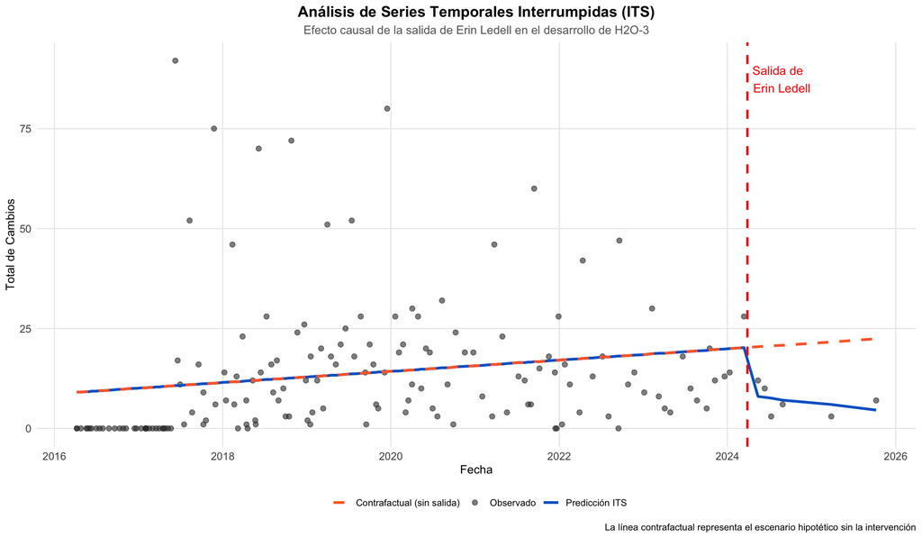

```r
# Crear predicciones
datos_pred <- datos %>%
  tidytable::mutate(
    pred_total = predict(modelo_its_total),
    pred_contrafactual = predict(modelo_its_total,
    newdata = datos %>%
    tidytable::mutate(post_salida = 0, meses_post = 0))
  )

# Tema personalizado
tema_custom <- theme_minimal() +
  theme(
    plot.title = element_text(size = 14, face = "bold", hjust = 0.5),
    plot.subtitle = element_text(size = 11, hjust = 0.5, color = "gray40"),
    axis.title = element_text(size = 11),
    axis.text = element_text(size = 10),
    legend.position = "bottom",
    legend.title = element_text(size = 10, face = "bold"),
    panel.grid.minor = element_blank()
  )

ggplot(datos_pred, aes(x = fecha)) +
  geom_point(aes(y = total_cambios, color = "Observado"), size = 2, alpha = 0.6) +
  geom_line(aes(y = pred_total, color = "Predicción ITS"), linewidth = 1.2) +
  geom_line(aes(y = pred_contrafactual, color = "Contrafactual (sin salida)"),
    linewidth = 1.2, linetype = "dashed") +
  geom_vline(xintercept = as.numeric(as.Date("2024-03-28")),
    linetype = "dashed", color = "red", linewidth = 1) +
  annotate("text", x = as.Date("2024-03-28"), y = max(datos$total_cambios) * 0.95,
    label = "Salida de
Erin Ledell", hjust = -0.1, color = "red", size = 4) +
  scale_color_manual(values = c(
    "Observado" = "#3333",
    "Predicción ITS" = "#0066CC",
    "Contrafactual (sin salida)" = "#FF6B35"
  )) +
  labs(
    title = "Análisis de Series Temporales Interrumpidas (ITS)",
    subtitle = "Efecto causal de la salida de Erin Ledell en el desarrollo de H2O-3",
    x = "Fecha",
    y = "Total de Cambios",
    color = "",
    caption = "La línea contrafactual representa el escenario hipotético sin la intervención"
  ) +
  tema_custom
```

**Interpretación:** El gráfico muestra el efecto causal estimado. La línea contrafactual (naranja discontinua) representa qué habría pasado sin la salida de Erin Ledell, mientras que la línea de predicción ITS (azul) muestra la trayectoria real ajustada por el modelo.

## 6.2 Evolución de Componentes Individuales

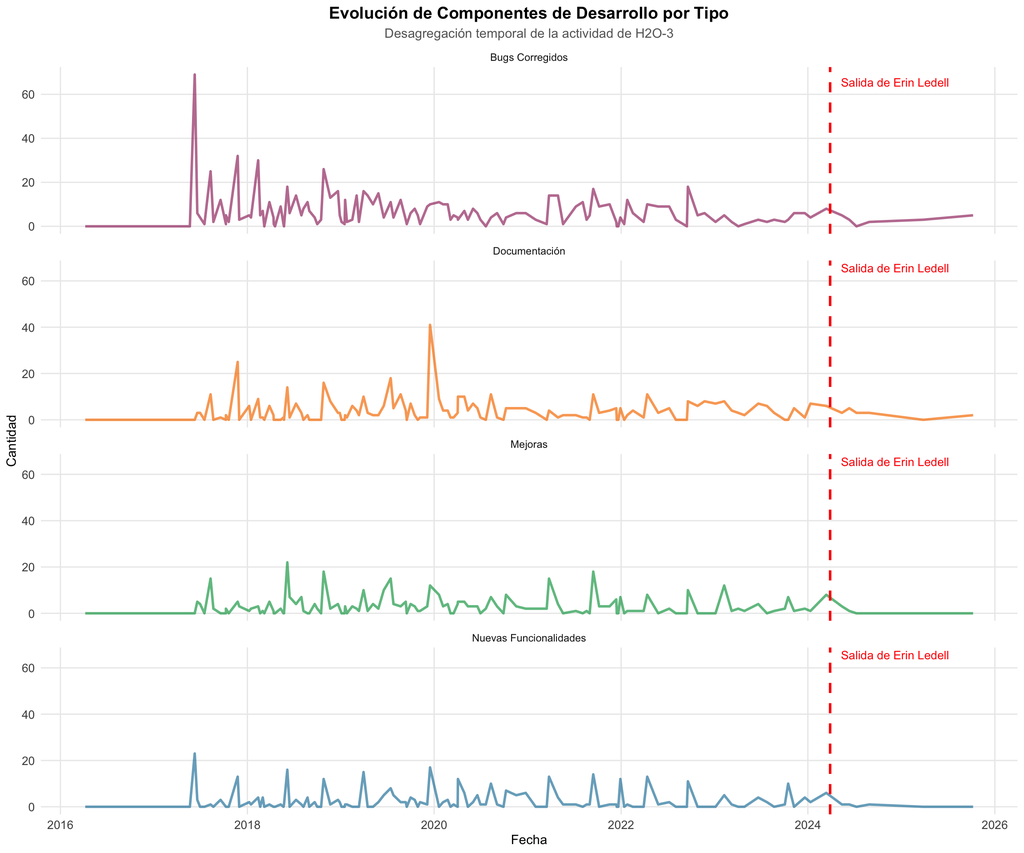

```r
# Preparar datos en formato largo
datos_long <- datos %>%
  tidytable::select(fecha, new_features, bugs, improvements, docs, periodo) %>%
  tidytable::pivot_longer(
    cols = c(new_features, bugs, improvements, docs),
    names_to = "tipo_cambio",
    values_to = "cantidad"
  ) %>%
  tidytable::mutate(
    tipo_cambio = tidytable::case_when(
    tipo_cambio == "new_features" ~ "Nuevas Funcionalidades",
    tipo_cambio == "bugs" ~ "Bugs Corregidos",
    tipo_cambio == "improvements" ~ "Mejoras",
    tipo_cambio == "docs" ~ "Documentación",
    TRUE ~ tipo_cambio
    )
  )

ggplot(datos_long, aes(x = fecha, y = cantidad, color = tipo_cambio)) +
  geom_line(linewidth = 1, alpha = 0.7) +
  geom_vline(xintercept = as.numeric(as.Date("2024-03-28")),
    linetype = "dashed", color = "red", linewidth = 1) +
  annotate("text", x = as.Date("2024-03-28"), y = max(datos_long$cantidad) * 0.95,
    label = "Salida de Erin Ledell", hjust = -0.1, color = "red", size = 3.5) +
  facet_wrap(~ tipo_cambio, scales = "free_y", ncol = 1) +
  scale_color_manual(values = c(
    "Nuevas Funcionalidades" = "#2E86AB",
    "Bugs Corregidos" = "#A23B72",
    "Mejoras" = "#18A558",
    "Documentación" = "#F77F00"
  )) +
  labs(
    title = "Evolución de Componentes de Desarrollo por Tipo",
    subtitle = "Desagregación temporal de la actividad de H2O-3",
    x = "Fecha",
    y = "Cantidad",
    color = "Tipo de Cambio"
  ) +
  tema_custom +
  theme(legend.position = "none")
```

## 6.3 Distribuciones Comparativas

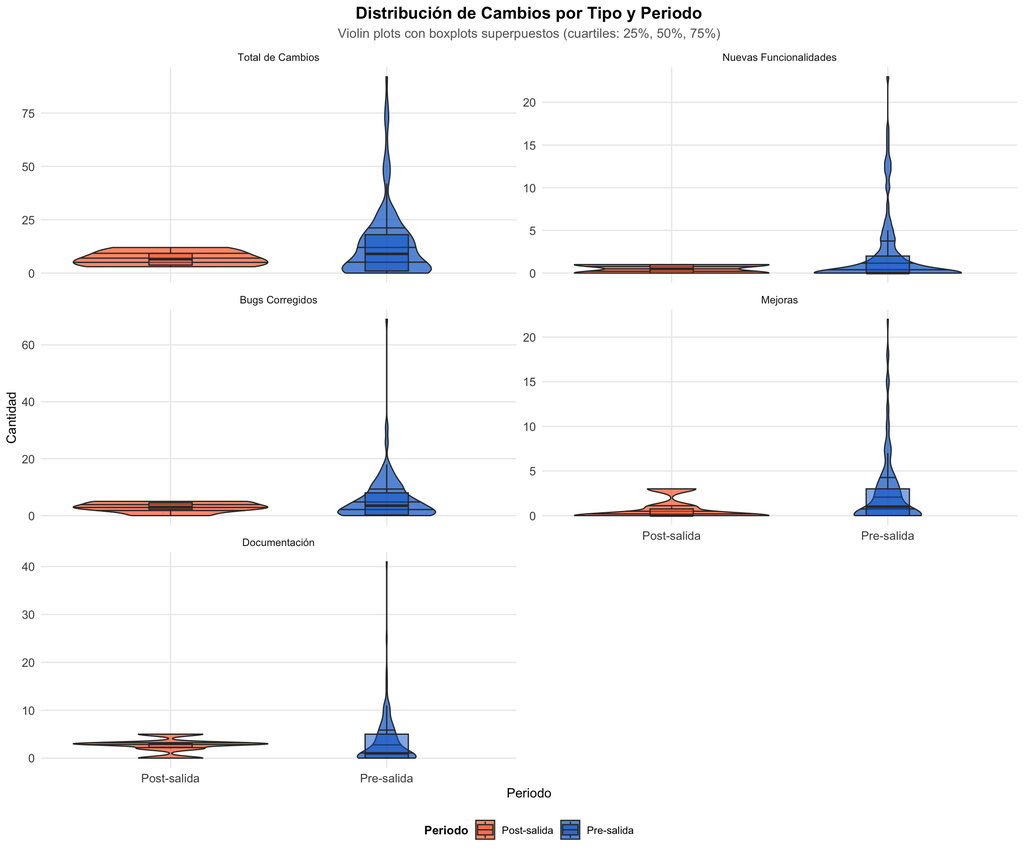

```r
# Preparar datos para violin plots
datos_long_comp <- datos %>%
  tidytable::select(periodo, new_features, bugs, improvements, docs, total_cambios) %>%
  tidytable::pivot_longer(
    cols = c(new_features, bugs, improvements, docs, total_cambios),
    names_to = "tipo_cambio",
    values_to = "cantidad"
  ) %>%
  tidytable::mutate(
    tipo_cambio = tidytable::case_when(
    tipo_cambio == "new_features" ~ "Nuevas Funcionalidades",
    tipo_cambio == "bugs" ~ "Bugs Corregidos",
    tipo_cambio == "improvements" ~ "Mejoras",
    tipo_cambio == "docs" ~ "Documentación",
    tipo_cambio == "total_cambios" ~ "Total de Cambios",
    TRUE ~ tipo_cambio
    ),
    tipo_cambio = factor(tipo_cambio, levels = c(
    "Total de Cambios", "Nuevas Funcionalidades",
    "Bugs Corregidos", "Mejoras", "Documentación"
    ))
  )

ggplot(datos_long_comp, aes(x = periodo, y = cantidad, fill = periodo)) +
  geom_violin(alpha = 0.7, draw_quantiles = c(0.25, 0.5, 0.75)) +
  geom_boxplot(width = 0.2, alpha = 0.5, outlier.shape = NA) +
  facet_wrap(~ tipo_cambio, scales = "free_y", ncol = 2) +
  scale_fill_manual(values = c("Pre-salida" = "#0066CC", "Post-salida" = "#FF6B35")) +
  labs(
    title = "Distribución de Cambios por Tipo y Periodo",
    subtitle = "Violin plots con boxplots superpuestos (cuartiles: 25%, 50%, 75%)",
    x = "Periodo",
    y = "Cantidad",
    fill = "Periodo"
  ) +
  tema_custom
```

**Interpretación:** Los violin plots muestran la distribución completa de cada variable. Las líneas en los violines representan los cuartiles (25%, 50% mediana, 75%). La reducción en ambos la ubicación y la dispersión indica un cambio sistemático en la actividad de desarrollo.

## 6.4 Tiempo Entre Versiones

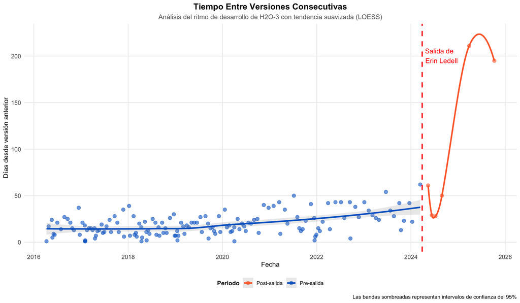

```r
datos_ritmo <- datos %>%
  tidytable::filter(dias_desde_anterior > 0)

ggplot(datos_ritmo, aes(x = fecha, y = dias_desde_anterior, color = periodo)) +
  geom_point(size = 2.5, alpha = 0.6) +
  geom_smooth(method = "loess", se = TRUE, alpha = 0.2, linewidth = 1.2) +
  geom_vline(xintercept = as.numeric(as.Date("2024-03-28")),
    linetype = "dashed", color = "red", linewidth = 1) +
  annotate("text", x = as.Date("2024-03-28"),
    y = max(datos_ritmo$dias_desde_anterior) * 0.95,
    label = "Salida de
Erin Ledell", hjust = -0.1, color = "red", size = 4) +
  scale_color_manual(values = c("Pre-salida" = "#0066CC", "Post-salida" = "#FF6B35")) +
  labs(
    title = "Tiempo Entre Versiones Consecutivas",
    subtitle = "Análisis del ritmo de desarrollo de H2O-3 con tendencia suavizada (LOESS)",
    x = "Fecha",
    y = "Días desde versión anterior",
    color = "Periodo",
    caption = "Las bandas sombreadas representan intervalos de confianza del 95%"
  ) +
  tema_custom
```

**Interpretación:** El incremento en el tiempo entre versiones post-salida sugiere una disminución en el ritmo de desarrollo. La tendencia suavizada (LOESS) muestra claramente este cambio.

## 6.5 Heatmap de Actividad Mensual

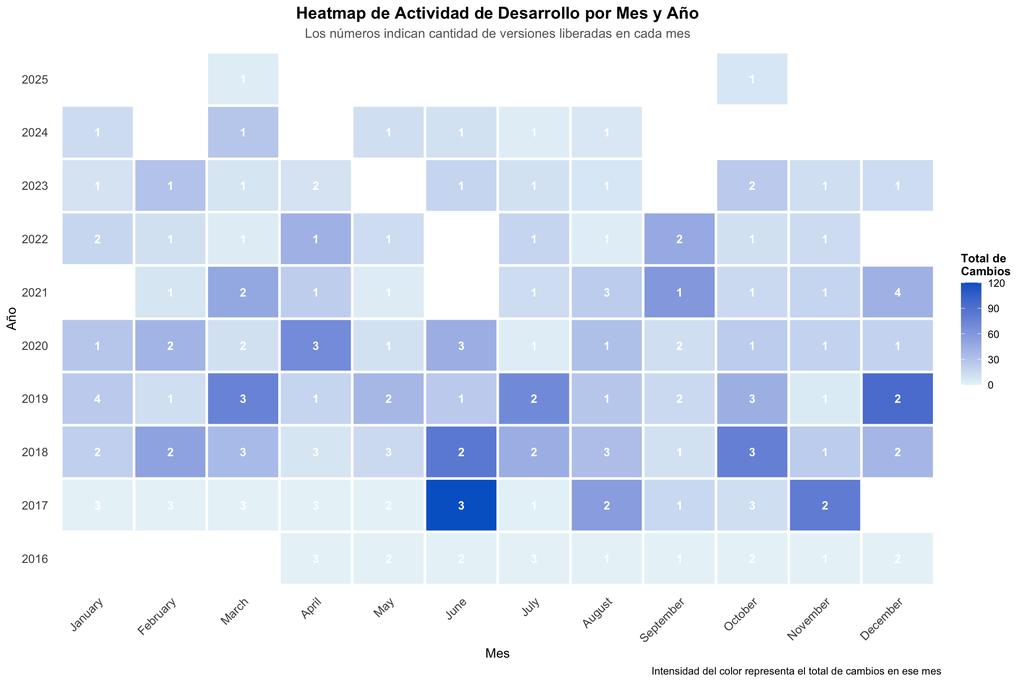

```r
datos_heatmap <- datos %>%
  tidytable::mutate(
    anio = year(fecha),
    mes = month(fecha, label = TRUE, abbr = FALSE)
  ) %>%
  tidytable::summarise(
    total_cambios_mes = sum(total_cambios, na.rm = TRUE),
    versiones_mes = n(),
    .by = c(anio, mes)
  )

ggplot(datos_heatmap, aes(x = mes, y = factor(anio), fill = total_cambios_mes)) +
  geom_tile(color = "white", linewidth = 1) +
  geom_text(aes(label = versiones_mes), color = "white", size = 3.5, fontface = "bold") +
  scale_fill_gradient(low = "#E8F4F8", high = "#0066CC",
    name = "Total de
Cambios",
    labels = comma) +
  labs(
    title = "Heatmap de Actividad de Desarrollo por Mes y Año",
    subtitle = "Los números indican cantidad de versiones liberadas en cada mes",
    x = "Mes",
    y = "Año",
    caption = "Intensidad del color representa el total de cambios en ese mes"
  ) +
  tema_custom +
  theme(
    axis.text.x = element_text(angle = 45, hjust = 1),
    legend.position = "right",
    panel.grid = element_blank()
  )
```

**Interpretación:** El heatmap permite identificar patrones estacionales y períodos de mayor o menor actividad. Los números indican la cantidad de versiones liberadas en cada celda.

## 6.6 Comparación de Medias

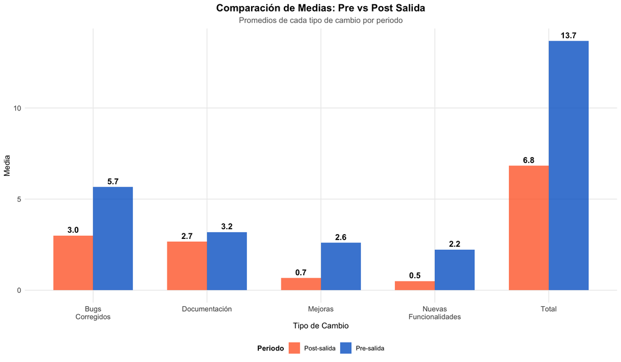

```r
datos_summary <- datos %>%
  tidytable::summarise(
    `Nuevas
Funcionalidades` = mean(new_features, na.rm = TRUE),
    `Bugs
Corregidos` = mean(bugs, na.rm = TRUE),
    `Mejoras` = mean(improvements, na.rm = TRUE),
    `Documentación` = mean(docs, na.rm = TRUE),
    `Total` = mean(total_cambios, na.rm = TRUE),
    .by = periodo
  ) %>%
  tidytable::pivot_longer(
    cols = -periodo,
    names_to = "tipo",
    values_to = "media"
  )

ggplot(datos_summary, aes(x = tipo, y = media, fill = periodo)) +
  geom_bar(stat = "identity", position = "dodge", alpha = 0.8, width = 0.7) +
  geom_text(aes(label = sprintf("%.1f", media)),
    position = position_dodge(width = 0.7),
    vjust = -0.5, size = 4, fontface = "bold") +
  scale_fill_manual(values = c("Pre-salida" = "#0066CC", "Post-salida" = "#FF6B35")) +
  labs(
    title = "Comparación de Medias: Pre vs Post Salida",
    subtitle = "Promedios de cada tipo de cambio por periodo",
    x = "Tipo de Cambio",
    y = "Media",
    fill = "Periodo"
  ) +
  tema_custom +
  theme(axis.text.x = element_text(angle = 0))
```

# 7 Análisis de Sensibilidad

## 7.1 Detección de Cambio Estructural

```r
# Serie temporal de total de cambios
ts_total <- datos$total_cambios

# Detectar cambios en media
cp_mean <- changepoint::cpt.mean(ts_total, method = "PELT")
fechas_cambio_mean <- datos$fecha[cpts(cp_mean)]

cat("════
")
```

```
## ════
```

```r
cat("DETECCIÓN DE PUNTOS DE CAMBIO (Changepoint Detection)
")
```

```
## DETECCIÓN DE PUNTOS DE CAMBIO (Changepoint Detection)
```

```r
cat("════

")
```

```
## ════
```

```r
cat("📍 Puntos de cambio detectados en la MEDIA:
")
```

```
## 📍 Puntos de cambio detectados en la MEDIA:
```

```r
if (length(cpts(cp_mean)) > 0) {
  for (i in seq_along(cpts(cp_mean))) {
    cat(sprintf("   %d. Versión #%d (Fecha: %s)
",
    i, cpts(cp_mean)[i], fechas_cambio_mean[i]))
  }
} else {
  cat("   No se detectaron cambios estructurales significativos
")
}
```

```
##    1. Versión #31 (Fecha: 2017-05-21)
##    2. Versión #32 (Fecha: 2017-06-09)
##    3. Versión #33 (Fecha: 2017-06-19)
##    4. Versión #34 (Fecha: 2017-06-30)
##    5. Versión #35 (Fecha: 2017-07-17)
##    6. Versión #36 (Fecha: 2017-08-10)
##    7. Versión #37 (Fecha: 2017-08-21)
##    8. Versión #38 (Fecha: 2017-09-18)
##    9. Versión #39 (Fecha: 2017-10-09)
##    10. Versión #40 (Fecha: 2017-10-09)
##    11. Versión #41 (Fecha: 2017-10-20)
##    12. Versión #42 (Fecha: 2017-11-24)
##    13. Versión #43 (Fecha: 2017-11-30)
##    14. Versión #44 (Fecha: 2018-01-08)
##    15. Versión #45 (Fecha: 2018-01-15)
##    16. Versión #46 (Fecha: 2018-02-12)
##    17. Versión #47 (Fecha: 2018-02-20)
##    18. Versión #48 (Fecha: 2018-03-02)
##    19. Versión #49 (Fecha: 2018-03-08)
##    20. Versión #50 (Fecha: 2018-03-28)
##    21. Versión #51 (Fecha: 2018-04-13)
##    22. Versión #53 (Fecha: 2018-04-19)
##    23. Versión #54 (Fecha: 2018-05-11)
##    24. Versión #56 (Fecha: 2018-05-24)
##    25. Versión #57 (Fecha: 2018-06-06)
##    26. Versión #58 (Fecha: 2018-06-15)
##    27. Versión #59 (Fecha: 2018-07-10)
##    28. Versión #60 (Fecha: 2018-07-31)
##    29. Versión #61 (Fecha: 2018-08-08)
##    30. Versión #62 (Fecha: 2018-08-24)
##    31. Versión #64 (Fecha: 2018-09-21)
##    32. Versión #66 (Fecha: 2018-10-16)
##    33. Versión #67 (Fecha: 2018-10-26)
##    34. Versión #69 (Fecha: 2018-12-21)
##    35. Versión #70 (Fecha: 2018-12-28)
##    36. Versión #72 (Fecha: 2019-01-16)
##    37. Versión #73 (Fecha: 2019-01-18)
##    38. Versión #74 (Fecha: 2019-01-25)
##    39. Versión #75 (Fecha: 2019-02-15)
##    40. Versión #76 (Fecha: 2019-03-04)
```

[output cut: 37 more lines]

```
##    78. Versión #131 (Fecha: 2022-02-16)
##    79. Versión #132 (Fecha: 2022-03-30)
##    80. Versión #133 (Fecha: 2022-04-13)
##    81. Versión #135 (Fecha: 2022-07-08)
##    82. Versión #137 (Fecha: 2022-09-15)
##    83. Versión #138 (Fecha: 2022-09-19)
##    84. Versión #141 (Fecha: 2023-01-05)
##    85. Versión #142 (Fecha: 2023-02-08)
##    86. Versión #145 (Fecha: 2023-04-28)
##    87. Versión #146 (Fecha: 2023-06-21)
##    88. Versión #149 (Fecha: 2023-10-03)
##    89. Versión #150 (Fecha: 2023-10-16)
##    90. Versión #153 (Fecha: 2024-01-11)
##    91. Versión #154 (Fecha: 2024-03-13)
##    92. Versión #156 (Fecha: 2024-06-11)
```

```r
# Detectar cambios en varianza
cp_var <- changepoint::cpt.var(ts_total, method = "PELT")
fechas_cambio_var <- datos$fecha[cpts(cp_var)]

cat("
📊 Puntos de cambio detectados en la VARIANZA:
")
```

```
##
## 📊 Puntos de cambio detectados en la VARIANZA:
```

```r
if (length(cpts(cp_var)) > 0) {
  for (i in seq_along(cpts(cp_var))) {
    cat(sprintf("   %d. Versión #%d (Fecha: %s)
",
    i, cpts(cp_var)[i], fechas_cambio_var[i]))
  }
} else {
  cat("   No se detectaron cambios estructurales significativos
")
}
```

```
##    1. Versión #138 (Fecha: 2022-09-19)
```

```r
cat("
💡 INTERPRETACIÓN:
")
```

```
##
## 💡 INTERPRETACIÓN:
```

```r
cat("   Los puntos de cambio detectados algorítmicamente deben ser comparados
")
```

```
##    Los puntos de cambio detectados algorítmicamente deben ser comparados
```

```r
cat("   con la fecha de intervención (28/03/2024) para validar el análisis.
")
```

```
##    con la fecha de intervención (28/03/2024) para validar el análisis.
```

```r
cat("════
")
```

```
## ════
```

## 7.2 Robustez a Especificación del Modelo

```r
# Modelo alternativo: con término cuadrático para tendencia no lineal
modelo_cuadratico <- lm(
  total_cambios ~ meses_pasados + I(meses_pasados^2) + post_salida +
    meses_post,
  data = datos
)

# Modelo alternativo: sin interacción (solo level change)
modelo_solo_level <- lm(
  total_cambios ~ meses_pasados + post_salida,
  data = datos
)

# Comparar modelos
cat("
════
")
```

```
##
## ════
```

```r
cat("COMPARACIÓN DE ESPECIFICACIONES DE MODELOS
")
```

```
## COMPARACIÓN DE ESPECIFICACIONES DE MODELOS
```

```r
cat("════

")
```

```
## ════
```

```r
comparacion <- data.frame(
  Modelo = c("ITS Completo", "ITS Cuadrático", "Solo Level Change"),
  `R²` = c(
    summary(modelo_its_total)$r.squared,
    summary(modelo_cuadratico)$r.squared,
    summary(modelo_solo_level)$r.squared
  ),
  `R² Ajustado` = c(
    summary(modelo_its_total)$adj.r.squared,
    summary(modelo_cuadratico)$adj.r.squared,
    summary(modelo_solo_level)$adj.r.squared
  ),
  AIC = c(
    AIC(modelo_its_total),
    AIC(modelo_cuadratico),
    AIC(modelo_solo_level)
  ),
  BIC = c(
    BIC(modelo_its_total),
    BIC(modelo_cuadratico),
    BIC(modelo_solo_level)
  )
)

kable(comparacion,
    caption = "Tabla 4: Comparación de especificaciones de modelos",
    digits = 3,
    align = "lrrrr") %>%
  kable_styling(bootstrap_options = c("striped", "hover", "condensed"),
    full_width = FALSE)
```

Tabla 4: Comparación de especificaciones de modelos

| Modelo | R. | R..Ajustado | AIC | BIC |
| --- | --- | --- | --- | --- |
| ITS Completo | 0.037 | 0.019 | 1362.661 | 1378.037 |
| ITS Cuadrático | 0.107 | 0.084 | 1352.650 | 1371.101 |
| Solo Level Change | 0.037 | 0.025 | 1360.741 | 1373.041 |

```r
cat("
💡 INTERPRETACIÓN:
")
```

```
##
## 💡 INTERPRETACIÓN:
```

```r
cat("   - R² más alto indica mejor ajuste a los datos
")
```

```
##    - R² más alto indica mejor ajuste a los datos
```

```r
cat("   - AIC y BIC más bajos indican mejor balance entre ajuste y complejidad
")
```

```
##    - AIC y BIC más bajos indican mejor balance entre ajuste y complejidad
```

```r
cat("   - El modelo ITS completo es generalmente preferible por su flexibilidad
")
```

```
##    - El modelo ITS completo es generalmente preferible por su flexibilidad
```

```r
cat("════
")
```

```
## ════
```

# 8 Discusión

## 8.2 Limitaciones

1. **Causalidad vs Correlación:** Aunque el diseño ITS es cuasi-experimental, no podemos descartar completamente factores confundidores no observados
2. **Generalización:** Los resultados son específicos a H2O-3 y pueden no generalizarse a otros proyectos de código abierto
3. **Periodo post-intervención limitado:** Con relativamente pocas observaciones post-salida, las estimaciones de largo plazo deben interpretarse con cautela
4. **Calidad de datos:** Dependemos de la precisión de los registros de versiones

## 8.3 Implicaciones

### 8.3.1 Para H2O.ai (Organización)

- **Gestión de riesgo de persona clave:** Los resultados subrayan la importancia de la continuidad del liderazgo técnico
- **Planificación de sucesión:** Necesidad de estrategias para mitigar el impacto de salidas de personal clave
- **Documentación y transferencia de conocimiento:** Crítica para mantener el ritmo de desarrollo

### 8.3.2 Para Proyectos de Código Abierto

- **Dependencia de individuos:** Los proyectos pueden ser vulnerables a la salida de contribuyentes principales
- **Sostenibilidad:** Importancia de distribuir conocimiento y responsabilidades

# 9 Conclusiones

## 9.2 Recomendaciones

### 9.2.1 Para H2O.ai (Organización)

1. **Planificación de Sucesión:**
   - Implementar planes de sucesión formales para roles técnicos clave
   - Identificar y desarrollar liderazgo técnico interno
2. **Transferencia de Conocimiento:**
   - Establecer procesos robustos de documentación y transferencia
   - Crear redundancia en conocimientos críticos
3. **Monitoreo de Métricas:**
   - Implementar dashboards para monitorear salud del desarrollo
   - Establecer alertas tempranas para cambios en productividad

### 9.2.2 Para la Comunidad de Código Abierto

1. **Distribución de Responsabilidades:**
   - Evitar concentración excesiva de conocimiento en individuos
   - Fomentar contribuciones diversificadas
2. **Incentivos para Mantenedores:**
   - Reconocer y compensar adecuadamente a contribuyentes clave
   - Crear estructuras que faciliten la transición de liderazgo

# 10 Referencias

## 10.1 Metodología

- Campbell, D. T., & Stanley, J. C. (1963). *Experimental and quasi-experimental designs for research*. Boston: Houghton Mifflin.
- Bernal, J. L., Cummins, S., & Gasparrini, A. (2017). Interrupted time series regression for the evaluation of public health interventions: a tutorial. *International journal of epidemiology*, 46(1), 348-355.
- Wagner, A. K., et al. (2002). Segmented regression analysis of interrupted time series studies in medication use research. *Journal of clinical pharmacy and therapeutics*, 27(4), 299-309.
- Newey, W. K., & West, K. D. (1987). A Simple, Positive Semi-definite, Heteroskedasticity and Autocorrelation Consistent Covariance Matrix. *Econometrica*, 55(3), 703-708.

## 10.2 Software

- R Core Team (2023). *R: A language and environment for statistical computing*. R Foundation for Statistical Computing, Vienna, Austria.
- Wickham, H. (2016). *ggplot2: Elegant Graphics for Data Analysis*. Springer-Verlag New York.
- Zeileis, A., & Hothorn, T. (2002). Diagnostic Checking in Regression Relationships. *R News*, 2(3), 7-10.
- Killick, R., & Eckley, I. A. (2014). changepoint: An R Package for Changepoint Analysis. *Journal of Statistical Software*, 58(3), 1-19.

# 11 Información de Sesión